# Introduction to R + OSM: Completed Notebook

This notebook provides an introduction to R, RStudio, and the osmdata packages. It’s intended for R beginners, so you can skip the first section if you have a background in R.

## Using R and RStudio

You can execute a chunk of code by putting your cursor in the chunk and pressing *Ctrl-Shift-Enter*, or by clicking the Run button (the green triangle) in the chunk. You can execute all code by clicking the Run button at the top of this document.

Try running the following code to check what packages you have installed:

```r
pkgs <- installed.packages()
head(pkgs)
```

```
##                Package
## abind          "abind"
## acs            "acs"
## AER            "AER"
## assertive      "assertive"
## assertive.base "assertive.base"
## assertive.code "assertive.code"
##                LibPath
## abind          "/Library/Frameworks/R.framework/Versions/3.4/Resources/library"
## acs            "/Library/Frameworks/R.framework/Versions/3.4/Resources/library"
## AER            "/Library/Frameworks/R.framework/Versions/3.4/Resources/library"
## assertive      "/Library/Frameworks/R.framework/Versions/3.4/Resources/library"
## assertive.base "/Library/Frameworks/R.framework/Versions/3.4/Resources/library"
## assertive.code "/Library/Frameworks/R.framework/Versions/3.4/Resources/library"
##                Version Priority
## abind          "1.4-5" NA
## acs            "2.1.3" NA
## AER            "1.2-5" NA
## assertive      "0.3-5" NA
## assertive.base "0.0-7" NA
## assertive.code "0.0-1" NA
##                Depends
## abind          "R (>= 1.5.0)"
## acs            "R (>= 2.10), stringr, methods, XML"
## AER            "R (>= 2.13.0), car (>= 2.0-19), lmtest, sandwich, survival (>=\n2.37-5), zoo"
## assertive      "R (>= 3.0.0)"
## assertive.base "R (>= 3.0.0)"
## assertive.code "R (>= 3.0.0)"
##                Imports
## abind          "methods, utils"
## acs            "graphics, stats, plyr, utils, httr"
## AER            "stats, Formula (>= 0.2-0)"
## assertive      "assertive.base (>= 0.0-4), assertive.properties (>= 0.0-2),\nassertive.types (>= 0.0-2), assertive.numbers,\nassertive.strings, assertive.datetimes, assertive.files,\nassertive.sets (>= 0.0-2), assertive.matrices,\nassertive.models, assertive.data, assertive.data.uk,\nassertive.da…
## assertive.base "methods, utils"
## assertive.code "assertive.base (>= 0.0-2), assertive.properties,\nassertive.types, methods"
##                LinkingTo
## abind          NA
## acs            NA
## AER            NA
## assertive      NA
```

[output cut: 15 more lines]

```
## assertive.code NA       "GPL (>= 3)"    NA
##                License_restricts_use OS_type MD5sum NeedsCompilation
## abind          NA                    NA      NA     "no"
## acs            NA                    NA      NA     "no"
## AER            NA                    NA      NA     "no"
## assertive      NA                    NA      NA     "no"
## assertive.base NA                    NA      NA     "no"
## assertive.code NA                    NA      NA     "no"
##                Built
## abind          "3.4.0"
## acs            "3.4.3"
## AER            "3.4.0"
## assertive      "3.4.0"
## assertive.base "3.4.0"
## assertive.code "3.4.0"
```

You can also count how many packages you have installed.

```r
nrow(pkgs)
```

```
## [1] 397
```

### Packages

What is a package anyway? It’s a way to extend R by grouping together useful functions (you can write your own and put it on Github/submit it to CRAN!). You should have already installed all the packages you need for this tutorial.

To update your installed packages, run the following command:

```r
update.packages()
```

To remove packages, run the following command:

```r
remove.packages("osmdata")
```

Before you use a package, you need to load it into your workspace with a library command. Here, we’re loading all the packages we need for this tutorial. Go ahead and load all the packages you just downloaded.

```r
library(magrittr)
library(osmdata)
library(sf)
library(sp)
```

## Download OSM data

The `osmdata` package works by taking R input, creating an Overpass API query, and returning the API output to R.

For the Overpass query, you need:

- The bounding box of your area
- The name of the feature you’re looking for (i.e. “name”, “highway”)
- The desired value of that feature (i.e. “Detroit”, “bikeway”)

The final overpass query looks something like this:

```r
opq(bbox = 'detroit') %>%
    add_osm_feature(key = 'highway', value = "cycleway") %>%
    osmdata_sp()
```

### Get the bounding box

Let’s look at how we can construct a query. First, let’s get the bounding box for Detroit.

```r
detroit_bb <- getbb(place_name = "detroit")
```

Pass the bounding box to the `opq()` command.

```r
opq(detroit_bb)
```

```
## $bbox
## [1] "42.255192,-83.287959,42.450232,-82.9104391"
##
## $prefix
## [1] "[out:xml][timeout:25];\n(\n"
##
## $suffix
## [1] ");\n(._;>;);\nout body;"
##
## $features
## NULL
##
## attr(,"class")
## [1] "list"           "overpass_query"
```

```r
opq(bbox = "detroit") # Produces the same thing
```

```
## $bbox
## [1] "42.255192,-83.287959,42.450232,-82.9104391"
##
## $prefix
## [1] "[out:xml][timeout:25];\n(\n"
##
## $suffix
## [1] ");\n(._;>;);\nout body;"
##
## $features
## NULL
##
## attr(,"class")
## [1] "list"           "overpass_query"
```

```r
opq(bbox = c(-83.287959,42.255192,-82.9104391,42.450232)) # Also produces the same thing
```

```
## $bbox
## [1] "42.255192,-83.287959,42.450232,-82.9104391"
##
## $prefix
## [1] "[out:xml][timeout:25];\n(\n"
##
## $suffix
## [1] ");\n(._;>;);\nout body;"
##
## $features
## NULL
##
## attr(,"class")
## [1] "list"           "overpass_query"
```

### Add the feature(s) we’re interested in

Let’s say we want to find all OSM cycleways in Detroit. Take the output from the previous section and add a feature!

```r
opq(detroit_bb) %>%
  add_osm_feature(key = "highway", value = "cycleway")
```

```
## $bbox
## [1] "42.255192,-83.287959,42.450232,-82.9104391"
##
## $prefix
## [1] "[out:xml][timeout:25];\n(\n"
##
## $suffix
## [1] ");\n(._;>;);\nout body;"
##
## $features
## [1] " [\"highway\"=\"cycleway\"]"
##
## attr(,"class")
## [1] "list"           "overpass_query"
```

Compare this to the output of the previous and you can see the `$features` section now has XML content.

#### Under the hood

What `osmdata` does is paste all this information together in a query that will work with the Overpass API. You can see the query that gets submitted to the API by using the `opq_string` function.

```r
opq(detroit_bb) %>%
  add_osm_feature(key = "highway", value = "cycleway") %>%
  opq_string()
```

```
## [1] "[out:xml][timeout:25];\n(\n node  [\"highway\"=\"cycleway\"] (42.255192,-83.287959,42.450232,-82.9104391);\n way  [\"highway\"=\"cycleway\"] (42.255192,-83.287959,42.450232,-82.9104391);\n relation  [\"highway\"=\"cycleway\"] (42.255192,-83.287959,42.450232,-82.9104391);\n\n);\n(._;>;);\nout…
```

#### How do I know the OSM names of the features I want?

For a list of all features, run the `available_features()` command:

```r
available_features()
```

```
##   [1] "4wd only"                "abandoned"
##   [3] "abutters"                "access"
##   [5] "addr"                    "addr:city"
##   [7] "addr:conscriptionnumber" "addr:country"
##   [9] "addr:district"           "addr:flats"
##  [11] "addr:full"               "addr:hamlet"
##  [13] "addr:housename"          "addr:housenumber"
##  [15] "addr:inclusion"          "addr:interpolation"
##  [17] "addr:place"              "addr:postcode"
##  [19] "addr:province"           "addr:state"
##  [21] "addr:street"             "addr:subdistrict"
##  [23] "addr:suburb"             "admin level"
##  [25] "aerialway"               "aeroway"
##  [27] "agricultural"            "alt name"
##  [29] "amenity"                 "area"
```

[output cut: 90 more lines]

And for the values associated with that feature, run the `available_tags` function:

```r
available_tags("highway")
```

```
##  [1] "bridleway"              "bus guideway"
##  [3] "bus stop"               "construction"
##  [5] "crossing"               "cycleway"
##  [7] "elevator"               "emergency access point"
##  [9] "escape"                 "footway"
## [11] "give way"               "living street"
## [13] "mini roundabout"        "motorway"
## [15] "motorway junction"      "motorway link"
## [17] "passing place"          "path"
## [19] "pedestrian"             "primary"
## [21] "primary link"           "proposed"
## [23] "raceway"                "residential"
## [25] "rest area"              "road"
## [27] "secondary"              "secondary link"
## [29] "service"                "services"
## [31] "speed camera"           "steps"
## [33] "stop"                   "street lamp"
## [35] "tertiary"               "tertiary link"
## [37] "toll gantry"            "track"
## [39] "traffic signals"        "trunk"
## [41] "trunk link"             "turning circle"
## [43] "unclassified"
```

### Submit query to Overpass API

Let’s submit this query to the Overpass API.

```r
opq(detroit_bb) %>%
  add_osm_feature(key = "highway", value = "cycleway") %>%
  osmdata_sp()
```

```
## Object of class 'osmdata' with:
##                  $bbox : 42.255192,-83.287959,42.450232,-82.9104391
##         $overpass_call : The call submitted to the overpass API
##             $timestamp : [ Wed 4 Oct 2018 17:30:24 ]
##            $osm_points : 'sp' SpatialPointsDataFrame with 2364 points
##             $osm_lines : 'sp' SpatialLinesDataFrame with 135 lines
##          $osm_polygons : 'sp' SpatialPolygonsDataFrame with 1 polygons
##        $osm_multilines : 'sp' SpatialNADataFrame with 0 multilines
##     $osm_multipolygons : 'sp' SpatialPolygonsDataFrame with 0 multipolygons
```

We request this back as an `sp` object, but I actually prefer `sf` objects for analysis. If you’ve used PostGIS before, `sf` data is essentially in the same format.

```r
opq(detroit_bb) %>%
  add_osm_feature(key = "highway", value = "cycleway") %>%
  osmdata_sf()
```

```
## Object of class 'osmdata' with:
##                  $bbox : 42.255192,-83.287959,42.450232,-82.9104391
##         $overpass_call : The call submitted to the overpass API
##             $timestamp : [ Wed 4 Oct 2018 17:30:25 ]
##            $osm_points : 'sf' Simple Features Collection with 2364 points
##             $osm_lines : 'sf' Simple Features Collection with 135 linestrings
##          $osm_polygons : 'sf' Simple Features Collection with 1 polygons
##        $osm_multilines : 'sf' Simple Features Collection with 0 multilinestrings
##     $osm_multipolygons : 'sf' Simple Features Collection with 0 multipolygons
```

However, for ease of mapping, I’m going to go ahead and use the `sp` data format. I’m going to save this as a local variable so I don’t have to hit the API each time.

```r
detroit_cycleways <- opq(detroit_bb) %>%
  add_osm_feature(key = "highway", value = "cycleway") %>%
  osmdata_sp()
```

### Map the output

Now let’s map the data!

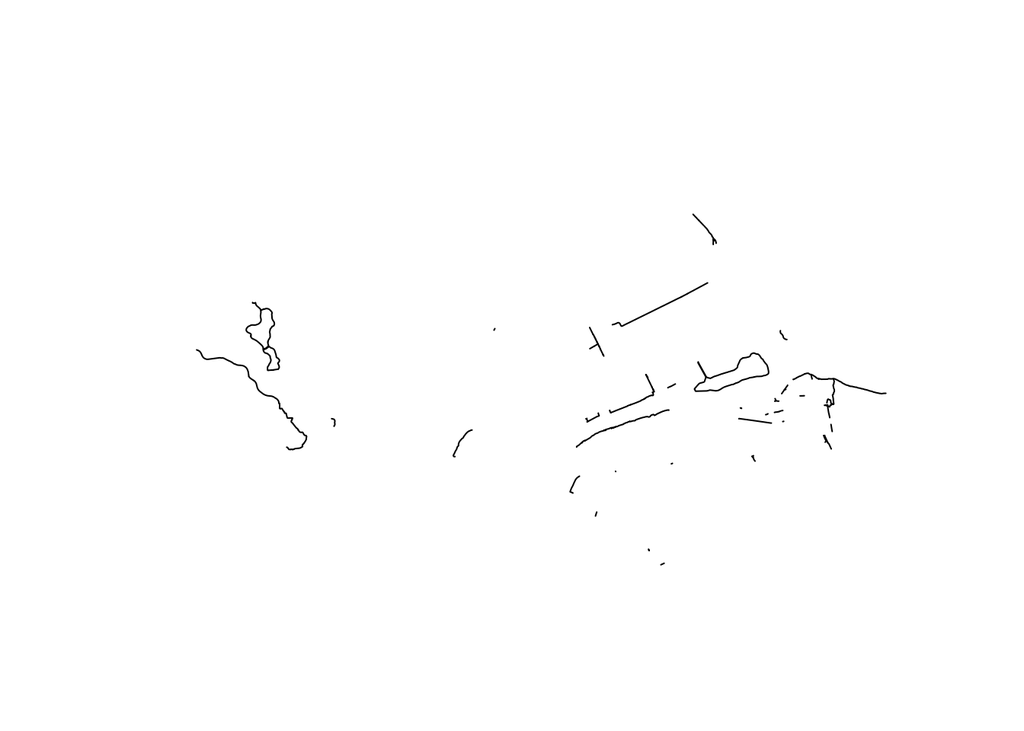

```r
plot(detroit_cycleways$osm_lines)
```

## Try it yourself

Maybe you want to add boundaries? Try a different features, or a different city? Try it out! Go to the [detailed lesson](https://ropensci.github.io/osmdata/articles/osmdata.html) and the [function reference](https://ropensci.github.io/osmdata/reference/index.html) for help.

Note that some data may take a while to download from Overpass.

FYI, this is the syntax for adding multiple features to the same map. You can unfortunately only do this with `sf` for the time being:

```r
kunming_water <- opq(bbox = 'Kunming, China') %>%
    add_osm_feature(key = 'natural', value = 'water') %>%
    osmdata_sf()

kunming_dian_names <- opq(bbox = 'Kunming, China') %>%
    add_osm_feature(key = 'name:en', value = 'Dian', value_exact = FALSE) %>%
    osmdata_sf()

kunming_all_features <- c(kunming_water, kunming_dian_names)
```

Also, to add multiple layers to a map with base R plotting (with sp), use the “add = T” syntax:

```r
# Can you make the detroit_boundaries variable on your own?
plot(detroit_cycleways$osm_lines)
plot(detroit_boundaries$osm_lines, add = T, col = "red")
```

```r
# Put your code here!
```